# Foundations of Data Science with R

## Agenda

1. Course Overview and Expectations
2. Example Analysis of Wine Prices

## Course Overview and Expectations

## About Me

- Background
  - BS in Computer Science from UC, Boulder
  - MBA from Willamette
  - Ph.D. in Marketing from U of A (minor in computational linguistics)
  - ~10 years programming professionally + ~10 years programming for research
- Contact
  - Website [jamesonwatts.github.io](https://jamesonwatts.github.io/)
  - Email: jwatts@willamette.edu
  - Office Hours: after class
  - Appointments: jamesonwatts.youcanbook.me (Skype or phone call)

## Class Materials

- [Base R](https://cran.r-project.org/)
- [RStudio 1.2](https://www.rstudio.com/products/rstudio/download)
- [R for Data Science](https://r4ds.had.co.nz)
- [DataCamp Classroom](https://www.datacamp.com/groups/shared_links/526ee016c61b2912b2bbc7a2f7fd1f1cf1ea3d09)

Other resources:

- https://twitter.com/r4dscommunity
- https://bookdown.org/yihui/rmarkdown
- http://google.com

## Reading the Course Outline

- From the [syllabus](https://github.com/jamesonwatts/GSMDS-5001/blob/master/syllabus/syllabus.pdf)
- Class Topics
  - Subjects I plan to cover during that day’s lecture
- Reading and Assignments
  - DCC: assignments in the DataCamp Classroom
  - R4ds: chapters to read in the online textbook

## Assignments

- DataCamp homework assignments (25%)
- Midterm exams (50%)
- Final Presentations and Report (25%)

## Course Policies and Expectations

- Name tents
- Collaboration
- Late work
- Effort
  - 2-4 hours outside of class each week
  - struggle, Google, StackExchange, struggle, Google, doh!
  - start with the basics… ramp up very fast

## Analysis of wine prices

## Overview of Data

- Grabbed from Kaggle [here](https://www.kaggle.com/zynicide/wine-reviews/)
- Scrape of wine reviews, scores, and prices from Wine Enthusiast during week of 6/15/2017
- Includes region, taster’s name, variety and winery
- 130k observations
- Some background reading [here](https://www.vivino.com/wine-news/how-much-does-a-good-bottle-of-wine-cost)

## Summarize Dataset

```
## Observations: 129,971
## Variables: 14
## $ id                    <dbl> 0, 1, 2, 3, 4, 5, 6, 7, 8, 9, 10, 11, 12, …
## $ country               <chr> "Italy", "Portugal", "US", "US", "US", "Sp…
## $ description           <chr> "Aromas include tropical fruit, broom, bri…
## $ designation           <chr> "Vulkà Bianco", "Avidagos", NA, "Reserve L…
## $ points                <dbl> 87, 87, 87, 87, 87, 87, 87, 87, 87, 87, 87…
## $ price                 <dbl> NA, 15, 14, 13, 65, 15, 16, 24, 12, 27, 19…
## $ province              <chr> "Sicily & Sardinia", "Douro", "Oregon", "M…
## $ region_1              <chr> "Etna", NA, "Willamette Valley", "Lake Mic…
## $ region_2              <chr> NA, NA, "Willamette Valley", NA, "Willamet…
## $ taster_name           <chr> "Kerin O’Keefe", "Roger Voss", "Paul Gregu…
## $ taster_twitter_handle <chr> "@kerinokeefe", "@vossroger", "@paulgwine …
## $ title                 <chr> "Nicosia 2013 Vulkà Bianco  (Etna)", "Quin…
## $ variety               <chr> "White Blend", "Portuguese Red", "Pinot Gr…
## $ winery                <chr> "Nicosia", "Quinta dos Avidagos", "Rainsto…
```

## Possible Research Questions

- What is the mean/median rating and cost of a bottle of red wine?
- Is wine from the Willamette Valley more or less expensive than wine from elsewhere?
  - Against which regions do we have a comparative advantage?
  - Where are we at a disadvantage?
- Do the most prolific tasters have a preference for a certain region or type of wine?
- What is the relationship between rating and price? Are there confounds?
- Are there certain words always associated with the highest rated wine?
- Which wines are a ‘good’ deal?

## Wine Prices (< $200) Histogram

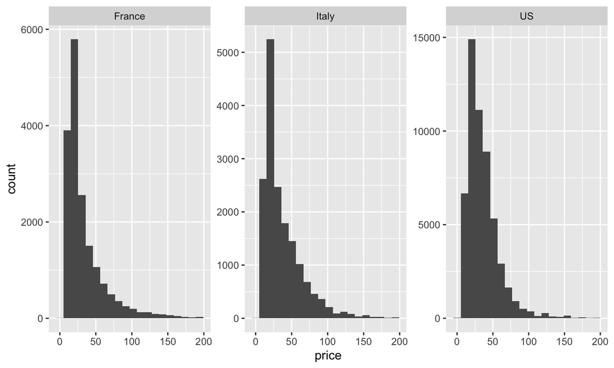

## Wine Prices (< $200) Density

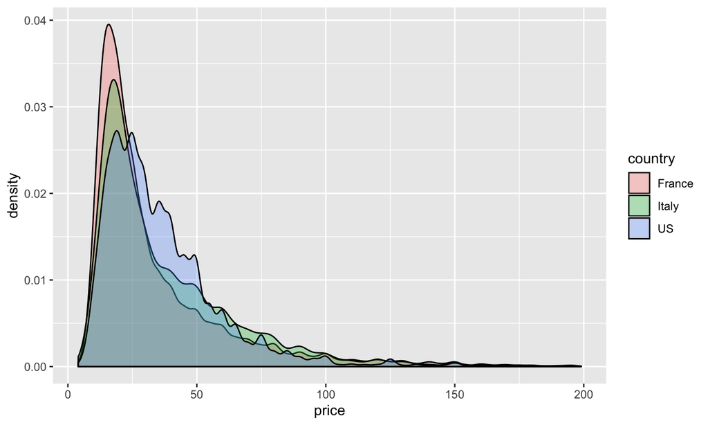

## Wine log(Prices) Density

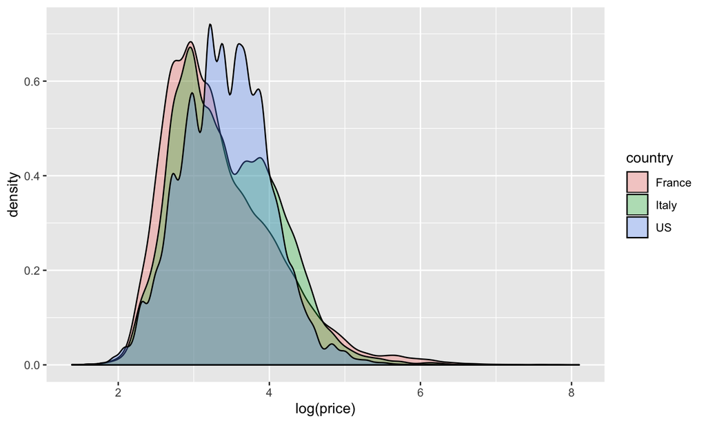

## Means and Medians

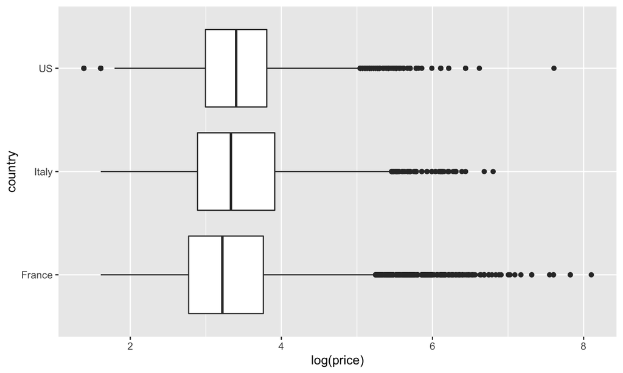

## Oregon vs. California vs. Bordeaux (Ratings)

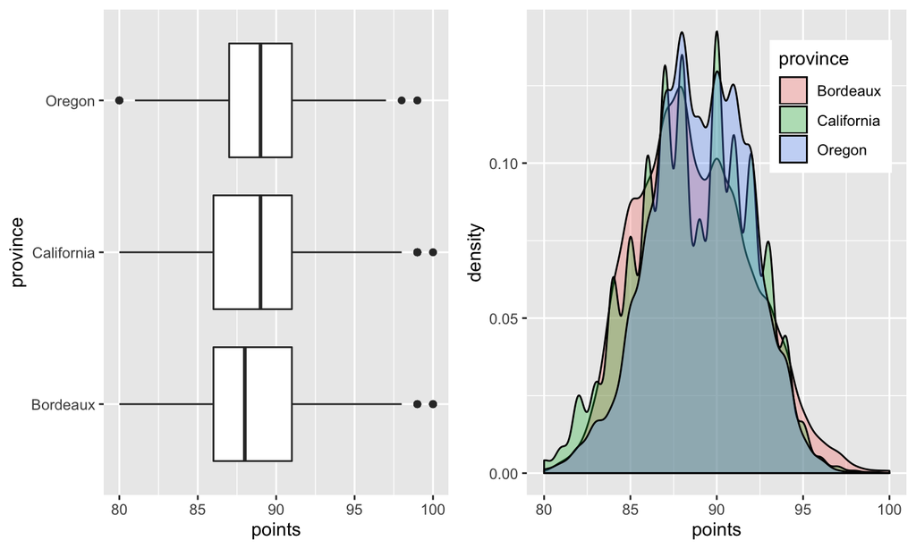

Ok, all pretty quality. How do we compare with Texas?

## Oregon vs. Texas (Ratings)

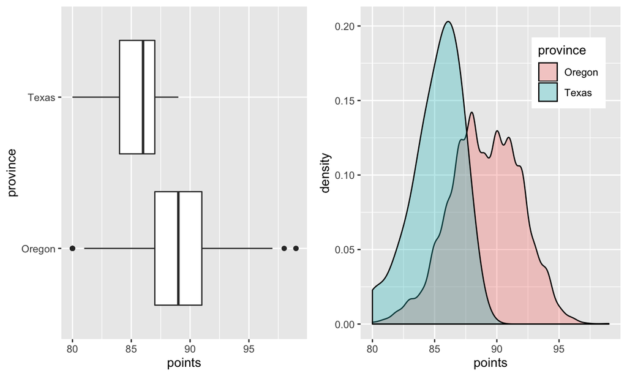

…thank goodness. Let’s get back to the relationship between ratings and price.

## Ratings and Price

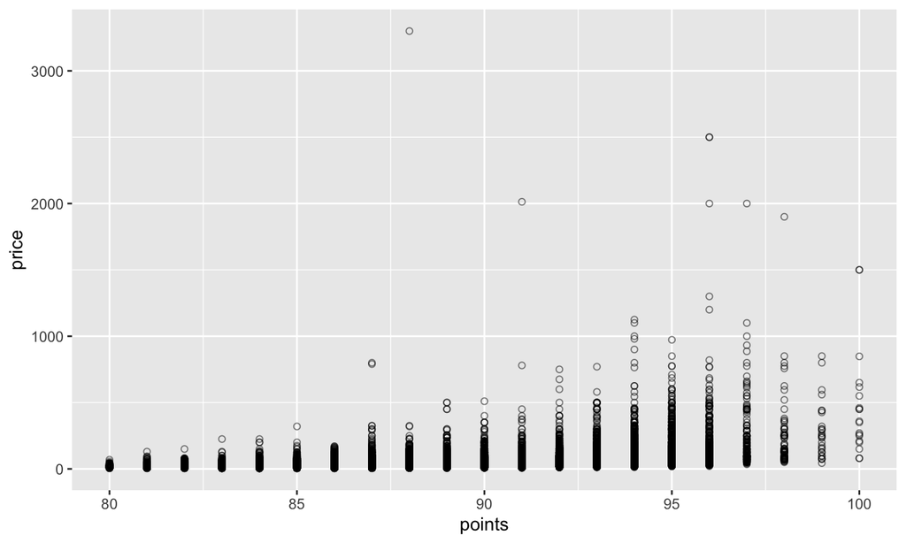

So perhaps we can start to see what is a ‘good’ deal and what isn’t. Let’s look at the crazy outliers.

## Who are the crazy outliers? (price > 1000)

```
## # A tibble: 14 x 5
##    points price country province   title
##     <dbl> <dbl> <chr>   <chr>      <chr>
##  1     88  3300 France  Bordeaux   Château les Ormes Sorbet 2013  Médoc
##  2     96  2500 France  Bordeaux   Château Pétrus 2014  Pomerol
##  3     96  2500 France  Burgundy   Domaine du Comte Liger-Belair 2010  La …
##  4     91  2013 US      California Blair 2013 Roger Rose Vineyard Chardonn…
##  5     97  2000 France  Bordeaux   Château Pétrus 2011  Pomerol
##  6     96  2000 France  Burgundy   Domaine du Comte Liger-Belair 2005  La …
##  7     98  1900 France  Bordeaux   Château Margaux 2009  Margaux
##  8    100  1500 France  Bordeaux   Château Lafite Rothschild 2010  Pauillac
##  9    100  1500 France  Bordeaux   Château Cheval Blanc 2010  Saint-Émilion
## 10     96  1300 France  Bordeaux   Château Mouton Rothschild 2009  Pauillac
## 11     96  1200 France  Bordeaux   Château Haut-Brion 2009  Pessac-Léognan
## 12     94  1125 France  Burgundy   Domaine du Comte Liger-Belair 2006  La …
## 13     97  1100 France  Bordeaux   Château La Mission Haut-Brion 2009  Pes…
## 14     94  1100 Austria Wachau     Emmerich Knoll 2013 Ried Loibenberg Sma…
```

…so there’s something going on with the French Bordeaux region. We should keep this in mind when we model price. But let’s get back to price/ratings relationship…

## Ratings x log(price)

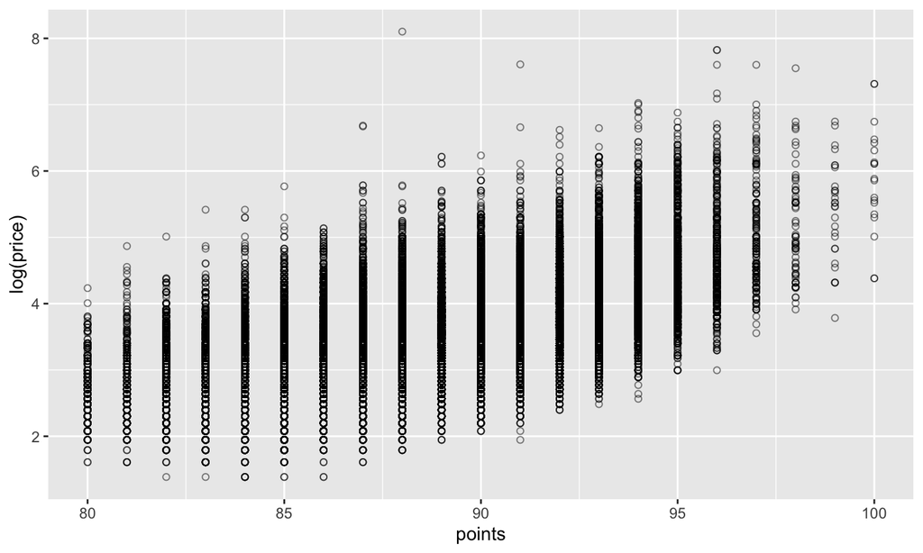

Okay, so the relationship is a bit clearer. But also, there is definitely some variance. Let’s first get an estimate of the slope and then see if things are different by region.

## Simple linear model

```
##
## Call:
## lm(formula = lprice ~ points, data = wine %>% mutate(lprice = log(price)))
##
## Residuals:
##     Min      1Q  Median      3Q     Max
## -1.7076 -0.3688 -0.0405  0.3177  4.8425
##
## Coefficients:
##               Estimate Std. Error t value Pr(>|t|)
## (Intercept) -8.3076501  0.0432237  -192.2   <2e-16 ***
## points       0.1314413  0.0004885   269.0   <2e-16 ***
## ---
## Signif. codes:  0 '***' 0.001 '**' 0.01 '*' 0.05 '.' 0.1 ' ' 1
##
## Residual standard error: 0.5173 on 120973 degrees of freedom
##   (8996 observations deleted due to missingness)
## Multiple R-squared:  0.3744, Adjusted R-squared:  0.3744
## F-statistic: 7.239e+04 on 1 and 120973 DF,  p-value: < 2.2e-16
```

Since we logged the DV, a 1 point ratings increase = `14.05`% increase in price on average. Note: \[ (e^x-1)*100 \]

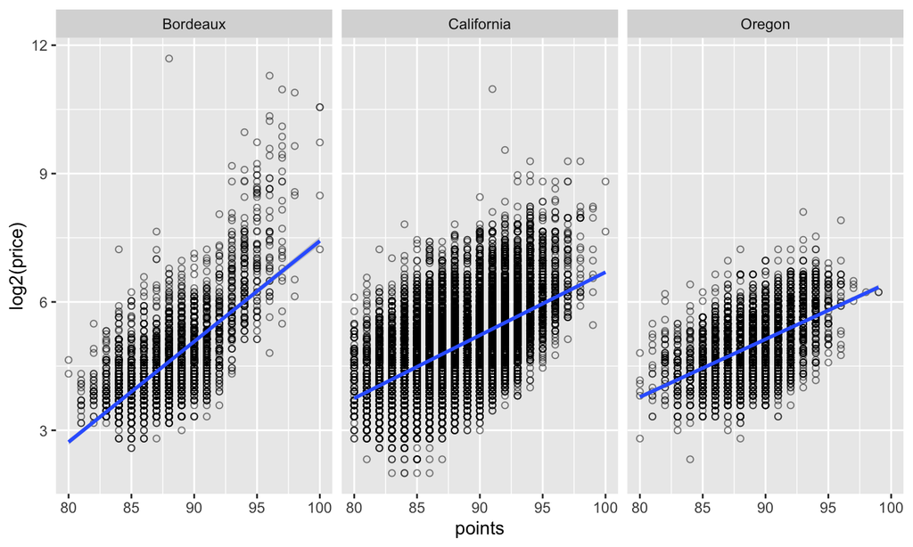

…so the slopes look different. Let’s actually run a model to see if they are.

## Linear models for each province

Bordeaux

```
## # A tibble: 2 x 7
##   term      estimate std_error statistic p_value lower_ci upper_ci
##   <chr>        <dbl>     <dbl>     <dbl>   <dbl>    <dbl>    <dbl>
## 1 intercept  -11.1       0.243     -45.9       0  -11.6    -10.7
## 2 points       0.163     0.003      59.1       0    0.157    0.168
```

California

```
## # A tibble: 2 x 7
##   term      estimate std_error statistic p_value lower_ci upper_ci
##   <chr>        <dbl>     <dbl>     <dbl>   <dbl>    <dbl>    <dbl>
## 1 intercept   -5.57      0.071     -78.9       0   -5.71    -5.44
## 2 points       0.102     0.001     128.        0    0.101    0.104
```

Oregon

```
## # A tibble: 2 x 7
##   term      estimate std_error statistic p_value lower_ci upper_ci
##   <chr>        <dbl>     <dbl>     <dbl>   <dbl>    <dbl>    <dbl>
## 1 intercept   -4.87      0.19      -25.7       0   -5.24    -4.50
## 2 points       0.094     0.002      43.9       0    0.089    0.098
```

What are the percent increases in price for each point by region?

## Cabernet or Rose?

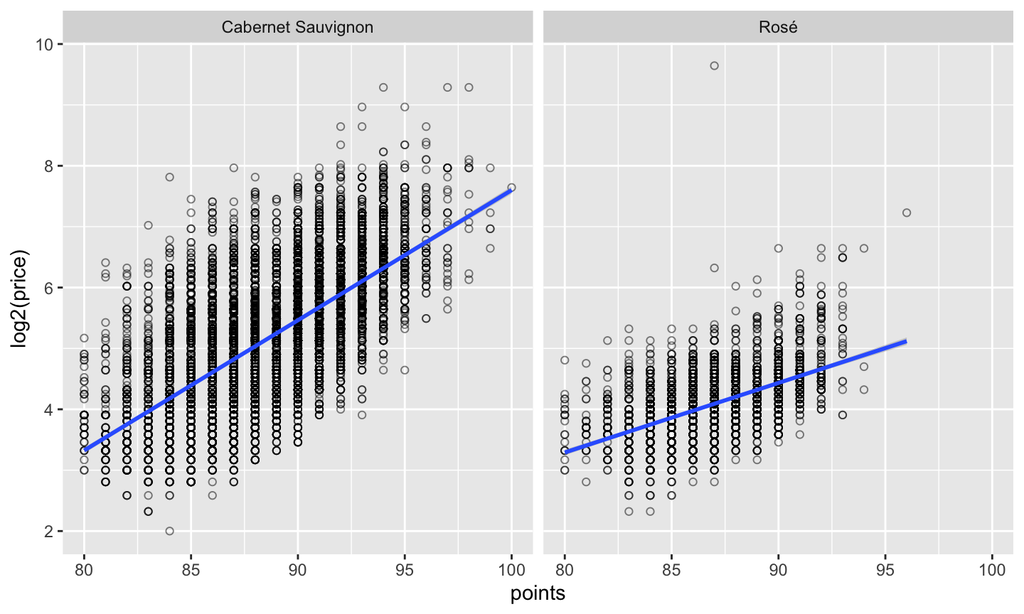